# Exploratory Data Analysis with Matplotlib and Plotly

Setting up the path

```python
cd C:\Users\HP-15\Documents\TMDB movie dataset
```

```
C:\Users\HP-15\Documents\TMDB movie dataset
```

```python
import pandas as pd
import numpy as np
import matplotlib.pyplot as plt
import json
import seaborn as sns
%matplotlib inline
import re
from wordcloud import WordCloud
```

```python
import plotly
plotly.tools.set_credentials_file(username='SakshamVikram', api_key='QoqXbiYSFGnkC40ovvMW')
```

```python
import plotly.plotly as py
import plotly.graph_objs as go
```

## Loading the Movies and Credits dataset

Many of the columns are in json which has to be converted back into normal forms.

```python
movies=pd.read_csv("tmdb_5000_movies.csv")
credits=pd.read_csv("tmdb_5000_credits.csv")
movie_json=['genres','keywords','production_countries','production_companies','spoken_languages',]
for col in movie_json:
    movies[col]=movies[col].apply(json.loads)
movies['release_date']=pd.to_datetime(movies['release_date'])

credits_json=['cast','crew']
for col in credits_json:
    credits[col]=credits[col].apply(json.loads)
```

### Here I try to find out the difference between columns Title and Original_title

```python
for i in range(len(movies.title)):
               if not movies.title[i]==movies.original_title[i]:
                   print([movies.title[i],movies.original_title[i]])
```

```
['Shin Godzilla', 'シン・ゴジラ']
['Fantastic 4: Rise of the Silver Surfer', '4: Rise of the Silver Surfer']
['Asterix at the Olympic Games', 'Astérix aux Jeux Olympiques']
['The Flowers of War', '金陵十三釵']
['Evolution', 'Évolution']
['Arthur and the Invisibles', 'Arthur et les Minimoys']
['Top Cat Begins', 'Don Gato: El inicio de la pandilla']
['Two Brothers', 'Deux frères']
['Dragon Blade', '天將雄師']
['This Is It', "Michael Jackson's This Is It"]
['The Monkey King 2', '西游记之孙悟空三打白骨精']
['A Very Long Engagement', 'Un long dimanche de fiançailles']
['The Messenger: The Story of Joan of Arc', 'Joan of Arc']
['Earth', '1947: Earth']
['Solaris', 'Солярис']
['Curse of the Golden Flower', '滿城盡帶黃金甲']
['Hero', '英雄']
['Micmacs', 'Micmacs à tire-larigot']
['Why I Did (Not) Eat My Father', "Pourquoi j'ai pas mangé mon père"]
['The Impossible', 'Lo imposible']
['Amélie', "Le fabuleux destin d'Amélie Poulain"]
['The Warlords', '投名狀']
['Nomad: The Warrior', 'Nomad']
['A Monster in Paris', 'Un monstre à Paris']
['Red Cliff', 'Chi bi']
['The Grandmaster', '一代宗師']
['The Inhabited Island', 'Obitaemyy Ostrov']
['Ip Man 3', '葉問3']
['The Horseman on the Roof', 'Le Hussard sur le toit']
['Ponyo', '崖の上のポニョ']
['Thunder and the House of Magic', 'The House of Magic']
['Dragon Wars: D-War', '디워']
['The Promise', 'Wu Ji']
['1911', '辛亥革命']
['Little Nicholas', 'Le petit Nicolas']
['Animals United', 'Konferenz der Tiere']
['Savva. Heart of the Warrior', 'Савва. Сердце воина']
['Space Pirate Captain Harlock', 'キャプテンハーロック']
['Winged Migration', 'Le peuple migrateur']
['The NeverEnding Story', 'The Neverending Story']
```

[output cut: 206 more lines]

```
['The Beyond', "...E tu vivrai nel terrore! L'aldilà"]
['Cries and Whispers', 'Viskningar och rop']
['Dogtooth', 'Κυνόδοντας']
["When the Cat's Away", 'Chacun Cherche Son Chat']
['Pierrot le Fou', 'Pierrot le fou']
['A Fistful of Dollars', 'Per un pugno di dollari']
['Three', 'Drei']
['American Beast', 'Solitude']
['The Case of the Grinning Cat', 'Chats perchés']
['Children of Heaven', 'بچه\u200cهای آسمان']
['The World Is Mine', 'Lumea e a mea']
['The Married Woman', "Une femme mariée: Suite de fragments d'un film tourné en 1964"]
['Gabriela', 'Gabriela, Cravo e Canela']
['The Circle', 'دایره']
['Cure', 'キュア']
```

```python
movies.info()
```

```
<class 'pandas.core.frame.DataFrame'>
RangeIndex: 4803 entries, 0 to 4802
Data columns (total 20 columns):
budget                  4803 non-null int64
genres                  4803 non-null object
homepage                1712 non-null object
id                      4803 non-null int64
keywords                4803 non-null object
original_language       4803 non-null object
original_title          4803 non-null object
overview                4800 non-null object
popularity              4803 non-null float64
production_companies    4803 non-null object
production_countries    4803 non-null object
release_date            4802 non-null object
revenue                 4803 non-null int64
runtime                 4801 non-null float64
spoken_languages        4803 non-null object
status                  4803 non-null object
tagline                 3959 non-null object
title                   4803 non-null object
vote_average            4803 non-null float64
vote_count              4803 non-null int64
dtypes: float64(3), int64(4), object(13)
memory usage: 750.5+ KB
```

```python
movies
```

|  | budget | genres | homepage | id | keywords | original_language | original_title | overview | popularity | production_companies | production_countries | release_date | revenue | runtime | spoken_languages | status | tagline | title | vote_average | vote_count |
| --- | --- | --- | --- | --- | --- | --- | --- | --- | --- | --- | --- | --- | --- | --- | --- | --- | --- | --- | --- | --- |
| 0 | 237000000 | [{'name': 'Action', 'id': 28}, {'name': 'Adven... | http://www.avatarmovie.com/ | 19995 | [{'name': 'culture clash', 'id': 1463}, {'name... | en | Avatar | In the 22nd century, a paraplegic Marine is di... | 150.437577 | [{'name': 'Ingenious Film Partners', 'id': 289... | [{'name': 'United States of America', 'iso_316... | 2009-12-10 | 2787965087 | 162.0 | [{'name': 'English', 'iso_639_1': 'en'}, {'nam... | Released | Enter the World of Pandora. | Avatar | 7.2 | 11800 |
| 1 | 300000000 | [{'name': 'Adventure', 'id': 12}, {'name': 'Fa... | http://disney.go.com/disneypictures/pirates/ | 285 | [{'name': 'ocean', 'id': 270}, {'name': 'drug ... | en | Pirates of the Caribbean: At World's End | Captain Barbossa, long believed to be dead, ha... | 139.082615 | [{'name': 'Walt Disney Pictures', 'id': 2}, {'... | [{'name': 'United States of America', 'iso_316... | 2007-05-19 | 961000000 | 169.0 | [{'name': 'English', 'iso_639_1': 'en'}] | Released | At the end of the world, the adventure begins. | Pirates of the Caribbean: At World's End | 6.9 | 4500 |
| 2 | 245000000 | [{'name': 'Action', 'id': 28}, {'name': 'Adven... | http://www.sonypictures.com/movies/spectre/ | 206647 | [{'name': 'spy', 'id': 470}, {'name': 'based o... | en | Spectre | A cryptic message from Bond’s past sends him o... | 107.376788 | [{'name': 'Columbia Pictures', 'id': 5}, {'nam... | [{'name': 'United Kingdom', 'iso_3166_1': 'GB'... | 2015-10-26 | 880674609 | 148.0 | [{'name': 'Français', 'iso_639_1': 'fr'}, {'na... | Released | A Plan No One Escapes | Spectre | 6.3 | 4466 |
| 3 | 250000000 | [{'name': 'Action', 'id': 28}, {'name': 'Crime... | http://www.thedarkknightrises.com/ | 49026 | [{'name': 'dc comics', 'id': 849}, {'name': 'c... | en | The Dark Knight Rises | Following the death of District Attorney Harve... | 112.312950 | [{'name': 'Legendary Pictures', 'id': 923}, {'... | [{'name': 'United States of America', 'iso_316... | 2012-07-16 | 1084939099 | 165.0 | [{'name': 'English', 'iso_639_1': 'en'}] | Released | The Legend Ends | The Dark Knight Rises | 7.6 | 9106 |
| 4 | 260000000 | [{'name': 'Action', 'id': 28}, {'name': 'Adven... | http://movies.disney.com/john-carter | 49529 | [{'name': 'based on novel', 'id': 818}, {'name... | en | John Carter | John Carter is a war-weary, former military ca... | 43.926995 | [{'name': 'Walt Disney Pictures', 'id': 2}] | [{'name': 'United States of America', 'iso_316... | 2012-03-07 | 284139100 | 132.0 | [{'name': 'English', 'iso_639_1': 'en'}] | Released | Lost in our world, found in another. | John Carter | 6.1 | 2124 |
| 5 | 258000000 | [{'name': 'Fantasy', 'id': 14}, {'name': 'Acti... | http://www.sonypictures.com/movies/spider-man3/ | 559 | [{'name': 'dual identity', 'id': 851}, {'name'... | en | Spider-Man 3 | The seemingly invincible Spider-Man goes up ag... | 115.699814 | [{'name': 'Columbia Pictures', 'id': 5}, {'nam... | [{'name': 'United States of America', 'iso_316... | 2007-05-01 | 890871626 | 139.0 | [{'name': 'English', 'iso_639_1': 'en'}, {'nam... | Released | The battle within. | Spider-Man 3 | 5.9 | 3576 |
| 6 | 260000000 | [{'name': 'Animation', 'id': 16}, {'name': 'Fa... | http://disney.go.com/disneypictures/tangled/ | 38757 | [{'name': 'hostage', 'id': 1562}, {'name': 'ma... | en | Tangled | When the kingdom's most wanted-and most charmi... | 48.681969 | [{'name': 'Walt Disney Pictures', 'id': 2}, {'... | [{'name': 'United States of America', 'iso_316... | 2010-11-24 | 591794936 | 100.0 | [{'name': 'English', 'iso_639_1': 'en'}] | Released | They're taking adventure to new lengths. | Tangled | 7.4 | 3330 |
| 7 | 280000000 | [{'name': 'Action', 'id': 28}, {'name': 'Adven... | http://marvel.com/movies/movie/193/avengers_ag... | 99861 | [{'name': 'marvel comic', 'id': 8828}, {'name'... | en | Avengers: Age of Ultron | When Tony Stark tries to jumpstart a dormant p... | 134.279229 | [{'name': 'Marvel Studios', 'id': 420}, {'name... | [{'name': 'United States of America', 'iso_316... | 2015-04-22 | 1405403694 | 141.0 | [{'name': 'English', 'iso_639_1': 'en'}] | Released | A New Age Has Come. | Avengers: Age of Ultron | 7.3 | 6767 |
| 8 | 250000000 | [{'name': 'Adventure', 'id': 12}, {'name': 'Fa... | http://harrypotter.warnerbros.com/harrypottera... | 767 | [{'name': 'witch', 'id': 616}, {'name': 'magic... | en | Harry Potter and the Half-Blood Prince | As Harry begins his sixth year at Hogwarts, he... | 98.885637 | [{'name': 'Warner Bros.', 'id': 6194}, {'name'... | [{'name': 'United Kingdom', 'iso_3166_1': 'GB'... | 2009-07-07 | 933959197 | 153.0 | [{'name': 'English', 'iso_639_1': 'en'}] | Released | Dark Secrets Revealed | Harry Potter and the Half-Blood Prince | 7.4 | 5293 |
| 9 | 250000000 | [{'name': 'Action', 'id': 28}, {'name': 'Adven... | http://www.batmanvsupermandawnofjustice.com/ | 209112 | [{'name': 'dc comics', 'id': 849}, {'name': 'v... | en | Batman v Superman: Dawn of Justice | Fearing the actions of a god-like Super Hero l... | 155.790452 | [{'name': 'DC Comics', 'id': 429}, {'name': 'A... | [{'name': 'United States of America', 'iso_316... | 2016-03-23 | 873260194 | 151.0 | [{'name': 'English', 'iso_639_1': 'en'}] | Released | Justice or revenge | Batman v Superman: Dawn of Justice | 5.7 | 7004 |
| 10 | 270000000 | [{'name': 'Adventure', 'id': 12}, {'name': 'Fa... | http://www.superman.com | 1452 | [{'name': 'saving the world', 'id': 83}, {'nam... | en | Superman Returns | Superman returns to discover his 5-year absenc... | 57.925623 | [{'name': 'DC Comics', 'id': 429}, {'name': 'L... | [{'name': 'United States of America', 'iso_316... | 2006-06-28 | 391081192 | 154.0 | [{'name': 'English', 'iso_639_1': 'en'}, {'nam... | Released | NaN | Superman Returns | 5.4 | 1400 |
| 11 | 200000000 | [{'name': 'Adventure', 'id': 12}, {'name': 'Ac... | http://www.mgm.com/view/movie/234/Quantum-of-S... | 10764 | [{'name': 'killing', 'id': 627}, {'name': 'und... | en | Quantum of Solace | Quantum of Solace continues the adventures of ... | 107.928811 | [{'name': 'Eon Productions', 'id': 7576}] | [{'name': 'United Kingdom', 'iso_3166_1': 'GB'... | 2008-10-30 | 586090727 | 106.0 | [{'name': 'English', 'iso_639_1': 'en'}, {'nam... | Released | For love, for hate, for justice, for revenge. | Quantum of Solace | 6.1 | 2965 |
| 12 | 200000000 | [{'name': 'Adventure', 'id': 12}, {'name': 'Fa... | http://disney.go.com/disneypictures/pirates/ | 58 | [{'name': 'witch', 'id': 616}, {'name': 'fortu... | en | Pirates of the Caribbean: Dead Man's Chest | Captain Jack Sparrow works his way out of a bl... | 145.847379 | [{'name': 'Walt Disney Pictures', 'id': 2}, {'... | [{'name': 'Jamaica', 'iso_3166_1': 'JM'}, {'na... | 2006-06-20 | 1065659812 | 151.0 | [{'name': 'English', 'iso_639_1': 'en'}, {'nam... | Released | Jack is back! | Pirates of the Caribbean: Dead Man's Chest | 7.0 | 5246 |
| 13 | 255000000 | [{'name': 'Action', 'id': 28}, {'name': 'Adven... | http://disney.go.com/the-lone-ranger/ | 57201 | [{'name': 'texas', 'id': 1556}, {'name': 'hors... | en | The Lone Ranger | The Texas Rangers chase down a gang of outlaws... | 49.046956 | [{'name': 'Walt Disney Pictures', 'id': 2}, {'... | [{'name': 'United States of America', 'iso_316... | 2013-07-03 | 89289910 | 149.0 | [{'name': 'English', 'iso_639_1': 'en'}] | Released | Never Take Off the Mask | The Lone Ranger | 5.9 | 2311 |
| 14 | 225000000 | [{'name': 'Action', 'id': 28}, {'name': 'Adven... | http://www.manofsteel.com/ | 49521 | [{'name': 'saving the world', 'id': 83}, {'nam... | en | Man of Steel | A young boy learns that he has extraordinary p... | 99.398009 | [{'name': 'Legendary Pictures', 'id': 923}, {'... | [{'name': 'United Kingdom', 'iso_3166_1': 'GB'... | 2013-06-12 | 662845518 | 143.0 | [{'name': 'English', 'iso_639_1': 'en'}] | Released | You will believe that a man can fly. | Man of Steel | 6.5 | 6359 |
| 15 | 225000000 | [{'name': 'Adventure', 'id': 12}, {'name': 'Fa... | NaN | 2454 | [{'name': 'based on novel', 'id': 818}, {'name... | en | The Chronicles of Narnia: Prince Caspian | One year after their incredible adventures in ... | 53.978602 | [{'name': 'Walt Disney', 'id': 5888}, {'name':... | [{'name': 'Czech Republic', 'iso_3166_1': 'CZ'... | 2008-05-15 | 419651413 | 150.0 | [{'name': 'English', 'iso_639_1': 'en'}] | Released | Hope has a new face. | The Chronicles of Narnia: Prince Caspian | 6.3 | 1630 |
| 16 | 220000000 | [{'name': 'Science Fiction', 'id': 878}, {'nam... | http://marvel.com/avengers_movie/ | 24428 | [{'name': 'new york', 'id': 242}, {'name': 'sh... | en | The Avengers | When an unexpected enemy emerges and threatens... | 144.448633 | [{'name': 'Paramount Pictures', 'id': 4}, {'na... | [{'name': 'United States of America', 'iso_316... | 2012-04-25 | 1519557910 | 143.0 | [{'name': 'English', 'iso_639_1': 'en'}] | Released | Some assembly required. | The Avengers | 7.4 | 11776 |
| 17 | 380000000 | [{'name': 'Adventure', 'id': 12}, {'name': 'Ac... | http://disney.go.com/pirates/index-on-stranger... | 1865 | [{'name': 'sea', 'id': 658}, {'name': 'captain... | en | Pirates of the Caribbean: On Stranger Tides | Captain Jack Sparrow crosses paths with a woma... | 135.413856 | [{'name': 'Walt Disney Pictures', 'id': 2}, {'... | [{'name': 'United States of America', 'iso_316... | 2011-05-14 | 1045713802 | 136.0 | [{'name': 'English', 'iso_639_1': 'en'}, {'nam... | Released | Live Forever Or Die Trying. | Pirates of the Caribbean: On Stranger Tides | 6.4 | 4948 |
| 18 | 225000000 | [{'name': 'Action', 'id': 28}, {'name': 'Comed... | http://www.sonypictures.com/movies/meninblack3/ | 41154 | [{'name': 'time travel', 'id': 4379}, {'name':... | en | Men in Black 3 | Agents J (Will Smith) and K (Tommy Lee Jones) ... | 52.035179 | [{'name': 'Amblin Entertainment', 'id': 56}, {... | [{'name': 'United States of America', 'iso_316... | 2012-05-23 | 624026776 | 106.0 | [{'name': 'English', 'iso_639_1': 'en'}] | Released | They are back... in time. | Men in Black 3 | 6.2 | 4160 |
| 19 | 250000000 | [{'name': 'Action', 'id': 28}, {'name': 'Adven... | http://www.thehobbit.com/ | 122917 | [{'name': 'corruption', 'id': 417}, {'name': '... | en | The Hobbit: The Battle of the Five Armies | Immediately after the events of The Desolation... | 120.965743 | [{'name': 'WingNut Films', 'id': 11}, {'name':... | [{'name': 'New Zealand', 'iso_3166_1': 'NZ'}, ... | 2014-12-10 | 956019788 | 144.0 | [{'name': 'English', 'iso_639_1': 'en'}] | Released | Witness the defining chapter of the Middle-Ear... | The Hobbit: The Battle of the Five Armies | 7.1 | 4760 |
| 20 | 215000000 | [{'name': 'Action', 'id': 28}, {'name': 'Adven... | http://www.theamazingspiderman.com | 1930 | [{'name': 'loss of father', 'id': 1872}, {'nam... | en | The Amazing Spider-Man | Peter Parker is an outcast high schooler aband... | 89.866276 | [{'name': 'Columbia Pictures', 'id': 5}, {'nam... | [{'name': 'United States of America', 'iso_316... | 2012-06-27 | 752215857 | 136.0 | [{'name': 'English', 'iso_639_1': 'en'}] | Released | The untold story begins. | The Amazing Spider-Man | 6.5 | 6586 |
| 21 | 200000000 | [{'name': 'Action', 'id': 28}, {'name': 'Adven... | http://www.robinhoodthemovie.com/ | 20662 | [{'name': 'robin hood', 'id': 4147}, {'name': ... | en | Robin Hood | When soldier Robin happens upon the dying Robe... | 37.668301 | [{'name': 'Imagine Entertainment', 'id': 23}, ... | [{'name': 'United Kingdom', 'iso_3166_1': 'GB'... | 2010-05-12 | 310669540 | 140.0 | [{'name': 'English', 'iso_639_1': 'en'}, {'nam... | Released | Rise and rise again, until lambs become lions. | Robin Hood | 6.2 | 1398 |
| 22 | 250000000 | [{'name': 'Adventure', 'id': 12}, {'name': 'Fa... | http://www.thehobbit.com/ | 57158 | [{'name': 'elves', 'id': 603}, {'name': 'dwarv... | en | The Hobbit: The Desolation of Smaug | The Dwarves, Bilbo and Gandalf have successful... | 94.370564 | [{'name': 'WingNut Films', 'id': 11}, {'name':... | [{'name': 'New Zealand', 'iso_3166_1': 'NZ'}, ... | 2013-12-11 | 958400000 | 161.0 | [{'name': 'English', 'iso_639_1': 'en'}] | Released | Beyond darkness... beyond desolation... lies t... | The Hobbit: The Desolation of Smaug | 7.6 | 4524 |
| 23 | 180000000 | [{'name': 'Adventure', 'id': 12}, {'name': 'Fa... | http://www.goldencompassmovie.com/index_german... | 2268 | [{'name': 'england', 'id': 392}, {'name': 'com... | en | The Golden Compass | After overhearing a shocking secret, precociou... | 42.990906 | [{'name': 'New Line Cinema', 'id': 12}, {'name... | [{'name': 'United Kingdom', 'iso_3166_1': 'GB'... | 2007-12-04 | 372234864 | 113.0 | [{'name': 'Íslenska', 'iso_639_1': 'is'}, {'na... | Released | There are worlds beyond our own - the compass ... | The Golden Compass | 5.8 | 1303 |
| 24 | 207000000 | [{'name': 'Adventure', 'id': 12}, {'name': 'Dr... | NaN | 254 | [{'name': 'film business', 'id': 774}, {'name'... | en | King Kong | In 1933 New York, an overly ambitious movie pr... | 61.226010 | [{'name': 'WingNut Films', 'id': 11}, {'name':... | [{'name': 'New Zealand', 'iso_3166_1': 'NZ'}, ... | 2005-12-14 | 550000000 | 187.0 | [{'name': 'English', 'iso_639_1': 'en'}] | Released | The eighth wonder of the world. | King Kong | 6.6 | 2337 |
| 25 | 200000000 | [{'name': 'Drama', 'id': 18}, {'name': 'Romanc... | http://www.titanicmovie.com | 597 | [{'name': 'shipwreck', 'id': 2580}, {'name': '... | en | Titanic | 84 years later, a 101-year-old woman named Ros... | 100.025899 | [{'name': 'Paramount Pictures', 'id': 4}, {'na... | [{'name': 'United States of America', 'iso_316... | 1997-11-18 | 1845034188 | 194.0 | [{'name': 'English', 'iso_639_1': 'en'}, {'nam... | Released | Nothing on Earth could come between them. | Titanic | 7.5 | 7562 |
| 26 | 250000000 | [{'name': 'Adventure', 'id': 12}, {'name': 'Ac... | http://marvel.com/captainamericapremiere | 271110 | [{'name': 'civil war', 'id': 393}, {'name': 'w... | en | Captain America: Civil War | Following the events of Age of Ultron, the col... | 198.372395 | [{'name': 'Studio Babelsberg', 'id': 264}, {'n... | [{'name': 'United States of America', 'iso_316... | 2016-04-27 | 1153304495 | 147.0 | [{'name': 'Română', 'iso_639_1': 'ro'}, {'name... | Released | Divided We Fall | Captain America: Civil War | 7.1 | 7241 |
| 27 | 209000000 | [{'name': 'Thriller', 'id': 53}, {'name': 'Act... | NaN | 44833 | [{'name': 'fight', 'id': 1721}, {'name': 'u.s.... | en | Battleship | When mankind beams a radio signal into space, ... | 64.928382 | [{'name': 'Universal Pictures', 'id': 33}, {'n... | [{'name': 'United States of America', 'iso_316... | 2012-04-11 | 303025485 | 131.0 | [{'name': 'English', 'iso_639_1': 'en'}, {'nam... | Released | The Battle for Earth Begins at Sea | Battleship | 5.5 | 2114 |
| 28 | 150000000 | [{'name': 'Action', 'id': 28}, {'name': 'Adven... | http://www.jurassicworld.com/ | 135397 | [{'name': 'monster', 'id': 1299}, {'name': 'dn... | en | Jurassic World | Twenty-two years after the events of Jurassic ... | 418.708552 | [{'name': 'Universal Studios', 'id': 13}, {'na... | [{'name': 'United States of America', 'iso_316... | 2015-06-09 | 1513528810 | 124.0 | [{'name': 'English', 'iso_639_1': 'en'}] | Released | The park is open. | Jurassic World | 6.5 | 8662 |
| 29 | 200000000 | [{'name': 'Action', 'id': 28}, {'name': 'Adven... | http://www.skyfall-movie.com | 37724 | [{'name': 'spy', 'id': 470}, {'name': 'secret ... | en | Skyfall | When Bond's latest assignment goes gravely wro... | 93.004993 | [{'name': 'Columbia Pictures', 'id': 5}] | [{'name': 'United Kingdom', 'iso_3166_1': 'GB'... | 2012-10-25 | 1108561013 | 143.0 | [{'name': 'English', 'iso_639_1': 'en'}] | Released | Think on your sins. | Skyfall | 6.9 | 7604 |
| ... | ... | ... | ... | ... | ... | ... | ... | ... | ... | ... | ... | ... | ... | ... | ... | ... | ... | ... | ... | ... |
| 4773 | 27000 | [{'name': 'Comedy', 'id': 35}] | http://www.miramax.com/movie/clerks/ | 2292 | [{'name': 'salesclerk', 'id': 1361}, {'name': ... | en | Clerks | Convenience and video store clerks Dante and R... | 19.748658 | [{'name': 'Miramax Films', 'id': 14}, {'name':... | [{'name': 'United States of America', 'iso_316... | 1994-09-13 | 3151130 | 92.0 | [{'name': 'English', 'iso_639_1': 'en'}] | Released | Just because they serve you doesn't mean they ... | Clerks | 7.4 | 755 |
| 4774 | 27000 | [{'name': 'Drama', 'id': 18}, {'name': 'Romanc... | NaN | 42497 | [{'name': 'dream', 'id': 1566}, {'name': 'pros... | en | Pink Narcissus | An erotic poem set in the fantasies of a young... | 0.027811 | [{'name': 'Strand Releasing', 'id': 3923}] | [{'name': 'United States of America', 'iso_316... | 1971-01-01 | 0 | 64.0 | [{'name': 'English', 'iso_639_1': 'en'}, {'nam... | Released | A unique experience in visual fantasy! | Pink Narcissus | 6.0 | 9 |
| 4775 | 0 | [{'name': 'Drama', 'id': 18}, {'name': 'Comedy... | NaN | 33693 | [{'name': 'mumblecore', 'id': 171993}] | en | Funny Ha Ha | Unsure of what to do next, 23-year-old Marnie ... | 0.362633 | [] | [{'name': 'United States of America', 'iso_316... | 2002-09-20 | 76901 | 85.0 | [{'name': 'English', 'iso_639_1': 'en'}] | Released | NaN | Funny Ha Ha | 6.3 | 8 |
| 4776 | 0 | [{'name': 'Comedy', 'id': 35}, {'name': 'Drama... | NaN | 14585 | [{'name': 'office', 'id': 1438}, {'name': 'lov... | en | In the Company of Men | Two business executives--one an avowed misogyn... | 2.634007 | [{'name': 'Alliance Atlantis Communications', ... | [{'name': 'Canada', 'iso_3166_1': 'CA'}, {'nam... | 1997-01-19 | 0 | 97.0 | [{'name': 'English', 'iso_639_1': 'en'}] | Released | Are all men bastards...or just misunderstood? | In the Company of Men | 6.8 | 44 |
| 4777 | 0 | [{'name': 'Drama', 'id': 18}] | NaN | 185465 | [] | en | Manito | Fifteen years ago, their Washington Heights ne... | 0.039264 | [] | [{'name': 'United States of America', 'iso_316... | 2002-01-15 | 0 | 78.0 | [{'name': 'Español', 'iso_639_1': 'es'}, {'nam... | Released | NaN | Manito | 5.5 | 2 |
| 4778 | 0 | [{'name': 'Action', 'id': 28}, {'name': 'Drama... | NaN | 38780 | [{'name': 'rampage', 'id': 10022}, {'name': 'm... | en | Rampage | The boredom of small town life is eating Bill ... | 7.101197 | [{'name': 'Boll Kino Beteiligungs GmbH & Co. K... | [{'name': 'Canada', 'iso_3166_1': 'CA'}, {'nam... | 2009-08-14 | 0 | 85.0 | [{'name': 'English', 'iso_639_1': 'en'}] | Released | Vengeance is ruthless. | Rampage | 6.0 | 131 |
| 4779 | 0 | [{'name': 'Comedy', 'id': 35}] | NaN | 14022 | [{'name': 'moon', 'id': 305}, {'name': 'philos... | en | Slacker | Presents a day in the life in Austin, Texas am... | 3.320622 | [] | [{'name': 'United States of America', 'iso_316... | 1990-07-27 | 0 | 97.0 | [{'name': 'English', 'iso_639_1': 'en'}] | Released | NaN | Slacker | 6.4 | 77 |
| 4780 | 0 | [{'name': 'Thriller', 'id': 53}, {'name': 'Cri... | NaN | 366967 | [] | en | Dutch Kills | A desperate ex-con is forced to gather his old... | 0.038143 | [] | [] | 2015-10-02 | 0 | 90.0 | [] | Released | NaN | Dutch Kills | 0.0 | 0 |
| 4781 | 22000 | [{'name': 'Comedy', 'id': 35}, {'name': 'Roman... | https://www.facebook.com/DrySpellMovie | 255266 | [{'name': 'dating', 'id': 13043}, {'name': 'di... | en | Dry Spell | Sasha tries to get her soon-to-be ex husband K... | 0.048948 | [] | [{'name': 'United States of America', 'iso_316... | 2013-02-14 | 0 | 90.0 | [{'name': 'English', 'iso_639_1': 'en'}] | Released | Getting divorced does funny things to a girl | Dry Spell | 6.0 | 1 |
| 4782 | 0 | [{'name': 'Drama', 'id': 18}, {'name': 'Family... | NaN | 17345 | [{'name': 'christianity', 'id': 186}, {'name':... | en | Flywheel | Jay Austin wants to sell you a used car, but w... | 1.048524 | [] | [{'name': 'United States of America', 'iso_316... | 2003-01-01 | 0 | 120.0 | [{'name': 'English', 'iso_639_1': 'en'}] | Released | NaN | Flywheel | 6.8 | 19 |
| 4783 | 0 | [{'name': 'Thriller', 'id': 53}, {'name': 'Hor... | NaN | 226458 | [{'name': 'possession', 'id': 9712}] | en | Backmask | During an all-night, drug-fueled party at an a... | 3.619167 | [{'name': 'GO Productions', 'id': 2943}, {'nam... | [{'name': 'United States of America', 'iso_316... | 2015-01-16 | 0 | 91.0 | [{'name': 'English', 'iso_639_1': 'en'}] | Released | nederlands | Backmask | 4.7 | 79 |
| 4784 | 0 | [{'name': 'Drama', 'id': 18}, {'name': 'Comedy... | http://www.thepuffychairmovie.com | 24055 | [{'name': 'mumblecore', 'id': 171993}] | en | The Puffy Chair | Josh's life is pretty much in the toilet. He's... | 1.243955 | [] | [] | 2005-01-17 | 0 | 85.0 | [] | Released | NaN | The Puffy Chair | 6.2 | 15 |
| 4785 | 0 | [{'name': 'Drama', 'id': 18}] | NaN | 287625 | [] | en | Stories of Our Lives | Created by the members of a Nairobi-based arts... | 0.327794 | [] | [{'name': 'Kenya', 'iso_3166_1': 'KE'}] | 2014-09-05 | 0 | 60.0 | [{'name': 'Kiswahili', 'iso_639_1': 'sw'}, {'n... | Released | NaN | Stories of Our Lives | 0.0 | 0 |
| 4786 | 0 | [{'name': 'Comedy', 'id': 35}, {'name': 'Roman... | NaN | 44990 | [{'name': 'independent film', 'id': 10183}] | en | Breaking Upwards | 'Breaking Upwards' explores a young, real-life... | 0.674570 | [] | [{'name': 'United States of America', 'iso_316... | 2009-03-14 | 0 | 88.0 | [{'name': 'English', 'iso_639_1': 'en'}] | Released | NaN | Breaking Upwards | 5.6 | 12 |
| 4787 | 0 | [{'name': 'Science Fiction', 'id': 878}, {'nam... | NaN | 86304 | [{'name': 'superhero', 'id': 9715}] | en | All Superheroes Must Die | Masked vigilantes Charge (Jason Trost), Cutthr... | 3.545991 | [{'name': 'Grindfest', 'id': 18818}] | [] | 2011-10-26 | 0 | 78.0 | [{'name': 'English', 'iso_639_1': 'en'}] | Released | May The Best Man Win | All Superheroes Must Die | 4.2 | 13 |
| 4788 | 12000 | [{'name': 'Horror', 'id': 27}, {'name': 'Comed... | NaN | 692 | [{'name': 'gay', 'id': 237}, {'name': 'trailer... | en | Pink Flamingos | Notorious Baltimore criminal and underground f... | 4.553644 | [{'name': 'Dreamland Productions', 'id': 407}] | [{'name': 'United States of America', 'iso_316... | 1972-03-12 | 6000000 | 93.0 | [{'name': 'English', 'iso_639_1': 'en'}] | Released | An exercise in poor taste. | Pink Flamingos | 6.2 | 110 |
| 4789 | 0 | [{'name': 'Drama', 'id': 18}] | NaN | 39851 | [{'name': 'addiction', 'id': 6782}, {'name': '... | en | Clean | After losing her husband to a heroin overdose,... | 1.464566 | [] | [{'name': 'United Kingdom', 'iso_3166_1': 'GB'... | 2004-09-01 | 0 | 111.0 | [{'name': '广州话 / 廣州話', 'iso_639_1': 'cn'}, {'n... | Released | When you don't have a choice, you change. | Clean | 6.7 | 17 |
| 4790 | 0 | [{'name': 'Drama', 'id': 18}, {'name': 'Foreig... | NaN | 13898 | [] | fa | دایره | Various women struggle to function in the oppr... | 1.193779 | [{'name': 'Jafar Panahi Film Productions', 'id... | [{'name': 'Iran', 'iso_3166_1': 'IR'}] | 2000-09-08 | 0 | 90.0 | [{'name': 'فارسی', 'iso_639_1': 'fa'}] | Released | NaN | The Circle | 6.6 | 17 |
| 4791 | 13 | [{'name': 'Horror', 'id': 27}] | http://tincanmanthemovie.com/ | 157185 | [{'name': 'home invasion', 'id': 14903}] | en | Tin Can Man | Recently dumped by his girlfirend for another ... | 0.332679 | [{'name': 'Park Films', 'id': 21871}, {'name':... | [{'name': 'Ireland', 'iso_3166_1': 'IE'}] | 2007-01-01 | 0 | 84.0 | [{'name': 'English', 'iso_639_1': 'en'}] | Released | Everything You've Heard is True | Tin Can Man | 2.0 | 1 |
| 4792 | 20000 | [{'name': 'Crime', 'id': 80}, {'name': 'Horror... | NaN | 36095 | [{'name': 'japan', 'id': 233}, {'name': 'prost... | ja | キュア | A wave of gruesome murders is sweeping Tokyo. ... | 0.212443 | [{'name': 'Daiei Studios', 'id': 881}] | [{'name': 'Japan', 'iso_3166_1': 'JP'}] | 1997-11-06 | 99000 | 111.0 | [{'name': '日本語', 'iso_639_1': 'ja'}] | Released | Madness. Terror. Murder. | Cure | 7.4 | 63 |
| 4793 | 0 | [{'name': 'Drama', 'id': 18}] | NaN | 182291 | [{'name': 'confession', 'id': 718}, {'name': '... | en | On The Downlow | Isaac and Angel are two young Latinos involved... | 0.029757 | [{'name': 'Iconoclast Films', 'id': 26677}] | [{'name': 'United States of America', 'iso_316... | 2004-04-11 | 0 | 90.0 | [] | Released | Two gangs. One secret. One crossroad. | On The Downlow | 6.0 | 2 |
| 4794 | 0 | [{'name': 'Thriller', 'id': 53}, {'name': 'Hor... | NaN | 286939 | [] | en | Sanctuary: Quite a Conundrum | It should have been just a normal day of sex, ... | 0.166513 | [{'name': 'Gold Lion Films', 'id': 37870}, {'n... | [{'name': 'United States of America', 'iso_316... | 2012-01-20 | 0 | 82.0 | [{'name': 'English', 'iso_639_1': 'en'}] | Released | NaN | Sanctuary: Quite a Conundrum | 0.0 | 0 |
| 4795 | 0 | [{'name': 'Drama', 'id': 18}] | NaN | 124606 | [{'name': 'gang', 'id': 10726}, {'name': 'audi... | en | Bang | A young woman in L.A. is having a bad day: she... | 0.918116 | [{'name': 'Asylum Films', 'id': 10571}, {'name... | [{'name': 'United States of America', 'iso_316... | 1995-09-09 | 0 | 98.0 | [{'name': 'English', 'iso_639_1': 'en'}] | Released | Sometimes you've got to break the rules | Bang | 6.0 | 1 |
| 4796 | 7000 | [{'name': 'Science Fiction', 'id': 878}, {'nam... | http://www.primermovie.com | 14337 | [{'name': 'distrust', 'id': 1448}, {'name': 'g... | en | Primer | Friends/fledgling entrepreneurs invent a devic... | 23.307949 | [{'name': 'Thinkfilm', 'id': 446}] | [{'name': 'United States of America', 'iso_316... | 2004-10-08 | 424760 | 77.0 | [{'name': 'English', 'iso_639_1': 'en'}] | Released | What happens if it actually works? | Primer | 6.9 | 658 |
| 4797 | 0 | [{'name': 'Foreign', 'id': 10769}, {'name': 'T... | NaN | 67238 | [] | en | Cavite | Adam, a security guard, travels from Californi... | 0.022173 | [] | [] | 2005-03-12 | 0 | 80.0 | [] | Released | NaN | Cavite | 7.5 | 2 |
| 4798 | 220000 | [{'name': 'Action', 'id': 28}, {'name': 'Crime... | NaN | 9367 | [{'name': 'united states–mexico barrier', 'id'... | es | El Mariachi | El Mariachi just wants to play his guitar and ... | 14.269792 | [{'name': 'Columbia Pictures', 'id': 5}] | [{'name': 'Mexico', 'iso_3166_1': 'MX'}, {'nam... | 1992-09-04 | 2040920 | 81.0 | [{'name': 'Español', 'iso_639_1': 'es'}] | Released | He didn't come looking for trouble, but troubl... | El Mariachi | 6.6 | 238 |
| 4799 | 9000 | [{'name': 'Comedy', 'id': 35}, {'name': 'Roman... | NaN | 72766 | [] | en | Newlyweds | A newlywed couple's honeymoon is upended by th... | 0.642552 | [] | [] | 2011-12-26 | 0 | 85.0 | [] | Released | A newlywed couple's honeymoon is upended by th... | Newlyweds | 5.9 | 5 |
| 4800 | 0 | [{'name': 'Comedy', 'id': 35}, {'name': 'Drama... | http://www.hallmarkchannel.com/signedsealeddel... | 231617 | [{'name': 'date', 'id': 248}, {'name': 'love a... | en | Signed, Sealed, Delivered | "Signed, Sealed, Delivered" introduces a dedic... | 1.444476 | [{'name': 'Front Street Pictures', 'id': 3958}... | [{'name': 'United States of America', 'iso_316... | 2013-10-13 | 0 | 120.0 | [{'name': 'English', 'iso_639_1': 'en'}] | Released | NaN | Signed, Sealed, Delivered | 7.0 | 6 |
| 4801 | 0 | [] | http://shanghaicalling.com/ | 126186 | [] | en | Shanghai Calling | When ambitious New York attorney Sam is sent t... | 0.857008 | [] | [{'name': 'United States of America', 'iso_316... | 2012-05-03 | 0 | 98.0 | [{'name': 'English', 'iso_639_1': 'en'}] | Released | A New Yorker in Shanghai | Shanghai Calling | 5.7 | 7 |
| 4802 | 0 | [{'name': 'Documentary', 'id': 99}] | NaN | 25975 | [{'name': 'obsession', 'id': 1523}, {'name': '... | en | My Date with Drew | Ever since the second grade when he first saw ... | 1.929883 | [{'name': 'rusty bear entertainment', 'id': 87... | [{'name': 'United States of America', 'iso_316... | 2005-08-05 | 0 | 90.0 | [{'name': 'English', 'iso_639_1': 'en'}] | Released | NaN | My Date with Drew | 6.3 | 16 |

4803 rows × 20 columns

#### Converting The Features back to make the notebook compatible with IMDB dataset which was takendown and I have heavily borrwoed from this kernel for the conversion.

```python
TMDB_TO_IMDB_SIMPLE_EQUIVALENCIES = {
    'budget': 'budget',
    'genres': 'genres',
    'revenue': 'gross',
    'title': 'movie_title',
    'runtime': 'duration',
    'original_language': 'language',  # it's possible that spoken_languages would be a better match
    'keywords': 'plot_keywords',
    'vote_count': 'num_voted_users',
                                         }

IMDB_COLUMNS_TO_REMAP = {'imdb_score': 'vote_average'}


def safe_access(container, index_values):
    # return a missing value rather than an error upon indexing/key failure
    result = container
    try:
        for idx in index_values:
            result = result[idx]
        return result
    except IndexError or KeyError:
        return pd.np.nan


def get_director(crew_data):
    directors = [x['name'] for x in crew_data if x['job'] == 'Director']
    return safe_access(directors, [0])


def pipe_flatten_names(keywords):
    return '|'.join([x['name'] for x in keywords])


def convert_format(movies, credits):
    # Converts TMDb data to make it as compatible as possible with kernels built on the original version of the data.
    tmdb_movies = movies.copy()
    tmdb_movies.rename(columns=TMDB_TO_IMDB_SIMPLE_EQUIVALENCIES, inplace=True)
    tmdb_movies['title_year'] = pd.to_datetime(tmdb_movies['release_date']).apply(lambda x: x.year)
    # I'm assuming that the first production country is equivalent, but have not been able to validate this
    tmdb_movies['country'] = tmdb_movies['production_countries'].apply(lambda x: safe_access(x, [0, 'name']))
    tmdb_movies['language'] = tmdb_movies['spoken_languages'].apply(lambda x: safe_access(x, [0, 'name']))
    tmdb_movies['director_name'] = credits['crew'].apply(get_director)
    tmdb_movies['actor_1_name'] = credits['cast'].apply(lambda x: safe_access(x, [0, 'name']))
    tmdb_movies['actor_2_name'] = credits['cast'].apply(lambda x: safe_access(x, [1, 'name']))
    tmdb_movies['actor_3_name'] = credits['cast'].apply(lambda x: safe_access(x, [2, 'name']))
    tmdb_movies['genres'] = tmdb_movies['genres'].apply(pipe_flatten_names)
    tmdb_movies['plot_keywords'] = tmdb_movies['plot_keywords'].apply(pipe_flatten_names)
    tmdb_movies['actor_1_gender']=credits['cast'].apply(lambda x:safe_access(x,[0,'gender']))
    tmdb_movies['actor_2_gender']=credits['cast'].apply(lambda x:safe_access(x,[1,'gender']))
    tmdb_movies['actor_3_gender']=credits['cast'].apply(lambda x:safe_access(x,[2,'gender']))


    return tmdb_movies
```

```python
tmdb_movies=convert_format(movies,credits)
cleaned=tmdb_movies.drop(['homepage','tagline'],axis=1).dropna(axis=0).reset_index()
```

```python
from sklearn import preprocessing
numerical_col=['budget','popularity','gross','num_voted_users','duration']
for col in numerical_col:
    cleaned[col]=preprocessing.scale(cleaned[col])
```

```python
tmdb_movies
```

|  | budget | genres | homepage | id | plot_keywords | language | original_title | overview | popularity | production_companies | ... | num_voted_users | title_year | country | director_name | actor_1_name | actor_2_name | actor_3_name | actor_1_gender | actor_2_gender | actor_3_gender |
| --- | --- | --- | --- | --- | --- | --- | --- | --- | --- | --- | --- | --- | --- | --- | --- | --- | --- | --- | --- | --- | --- |
| 0 | 237000000 | Action\|Adventure\|Fantasy\|Science Fiction | http://www.avatarmovie.com/ | 19995 | culture clash\|future\|space war\|space colony\|so... | English | Avatar | In the 22nd century, a paraplegic Marine is di... | 150.437577 | [{'name': 'Ingenious Film Partners', 'id': 289... | ... | 11800 | 2009.0 | United States of America | James Cameron | Zoe Saldana | Sigourney Weaver | Stephen Lang | 1.0 | 1.0 | 2.0 |
| 1 | 300000000 | Adventure\|Fantasy\|Action | http://disney.go.com/disneypictures/pirates/ | 285 | ocean\|drug abuse\|exotic island\|east india trad... | English | Pirates of the Caribbean: At World's End | Captain Barbossa, long believed to be dead, ha... | 139.082615 | [{'name': 'Walt Disney Pictures', 'id': 2}, {'... | ... | 4500 | 2007.0 | United States of America | Gore Verbinski | Orlando Bloom | Keira Knightley | Stellan Skarsgård | 2.0 | 1.0 | 2.0 |
| 2 | 245000000 | Action\|Adventure\|Crime | http://www.sonypictures.com/movies/spectre/ | 206647 | spy\|based on novel\|secret agent\|sequel\|mi6\|bri... | Français | Spectre | A cryptic message from Bond’s past sends him o... | 107.376788 | [{'name': 'Columbia Pictures', 'id': 5}, {'nam... | ... | 4466 | 2015.0 | United Kingdom | Sam Mendes | Christoph Waltz | Léa Seydoux | Ralph Fiennes | 2.0 | 1.0 | 2.0 |
| 3 | 250000000 | Action\|Crime\|Drama\|Thriller | http://www.thedarkknightrises.com/ | 49026 | dc comics\|crime fighter\|terrorist\|secret ident... | English | The Dark Knight Rises | Following the death of District Attorney Harve... | 112.312950 | [{'name': 'Legendary Pictures', 'id': 923}, {'... | ... | 9106 | 2012.0 | United States of America | Christopher Nolan | Michael Caine | Gary Oldman | Anne Hathaway | 2.0 | 2.0 | 1.0 |
| 4 | 260000000 | Action\|Adventure\|Science Fiction | http://movies.disney.com/john-carter | 49529 | based on novel\|mars\|medallion\|space travel\|pri... | English | John Carter | John Carter is a war-weary, former military ca... | 43.926995 | [{'name': 'Walt Disney Pictures', 'id': 2}] | ... | 2124 | 2012.0 | United States of America | Andrew Stanton | Lynn Collins | Samantha Morton | Willem Dafoe | 1.0 | 1.0 | 2.0 |
| 5 | 258000000 | Fantasy\|Action\|Adventure | http://www.sonypictures.com/movies/spider-man3/ | 559 | dual identity\|amnesia\|sandstorm\|love of one's ... | English | Spider-Man 3 | The seemingly invincible Spider-Man goes up ag... | 115.699814 | [{'name': 'Columbia Pictures', 'id': 5}, {'nam... | ... | 3576 | 2007.0 | United States of America | Sam Raimi | Kirsten Dunst | James Franco | Thomas Haden Church | 1.0 | 2.0 | 2.0 |
| 6 | 260000000 | Animation\|Family | http://disney.go.com/disneypictures/tangled/ | 38757 | hostage\|magic\|horse\|fairy tale\|musical\|princes... | English | Tangled | When the kingdom's most wanted-and most charmi... | 48.681969 | [{'name': 'Walt Disney Pictures', 'id': 2}, {'... | ... | 3330 | 2010.0 | United States of America | Byron Howard | Mandy Moore | Donna Murphy | Ron Perlman | 1.0 | 1.0 | 2.0 |
| 7 | 280000000 | Action\|Adventure\|Science Fiction | http://marvel.com/movies/movie/193/avengers_ag... | 99861 | marvel comic\|sequel\|superhero\|based on comic b... | English | Avengers: Age of Ultron | When Tony Stark tries to jumpstart a dormant p... | 134.279229 | [{'name': 'Marvel Studios', 'id': 420}, {'name... | ... | 6767 | 2015.0 | United States of America | Joss Whedon | Chris Hemsworth | Mark Ruffalo | Chris Evans | 2.0 | 2.0 | 2.0 |
| 8 | 250000000 | Adventure\|Fantasy\|Family | http://harrypotter.warnerbros.com/harrypottera... | 767 | witch\|magic\|broom\|school of witchcraft\|wizardr... | English | Harry Potter and the Half-Blood Prince | As Harry begins his sixth year at Hogwarts, he... | 98.885637 | [{'name': 'Warner Bros.', 'id': 6194}, {'name'... | ... | 5293 | 2009.0 | United Kingdom | David Yates | Rupert Grint | Emma Watson | Tom Felton | 2.0 | 1.0 | 2.0 |
| 9 | 250000000 | Action\|Adventure\|Fantasy | http://www.batmanvsupermandawnofjustice.com/ | 209112 | dc comics\|vigilante\|superhero\|based on comic b... | English | Batman v Superman: Dawn of Justice | Fearing the actions of a god-like Super Hero l... | 155.790452 | [{'name': 'DC Comics', 'id': 429}, {'name': 'A... | ... | 7004 | 2016.0 | United States of America | Zack Snyder | Henry Cavill | Gal Gadot | Amy Adams | 2.0 | 1.0 | 1.0 |
| 10 | 270000000 | Adventure\|Fantasy\|Action\|Science Fiction | http://www.superman.com | 1452 | saving the world\|dc comics\|invulnerability\|seq... | English | Superman Returns | Superman returns to discover his 5-year absenc... | 57.925623 | [{'name': 'DC Comics', 'id': 429}, {'name': 'L... | ... | 1400 | 2006.0 | United States of America | Bryan Singer | Kevin Spacey | Kate Bosworth | James Marsden | 2.0 | 1.0 | 2.0 |
| 11 | 200000000 | Adventure\|Action\|Thriller\|Crime | http://www.mgm.com/view/movie/234/Quantum-of-S... | 10764 | killing\|undercover\|secret agent\|british secret... | English | Quantum of Solace | Quantum of Solace continues the adventures of ... | 107.928811 | [{'name': 'Eon Productions', 'id': 7576}] | ... | 2965 | 2008.0 | United Kingdom | Marc Forster | Olga Kurylenko | Mathieu Amalric | Judi Dench | 1.0 | 2.0 | 1.0 |
| 12 | 200000000 | Adventure\|Fantasy\|Action | http://disney.go.com/disneypictures/pirates/ | 58 | witch\|fortune teller\|bondage\|exotic island\|mon... | English | Pirates of the Caribbean: Dead Man's Chest | Captain Jack Sparrow works his way out of a bl... | 145.847379 | [{'name': 'Walt Disney Pictures', 'id': 2}, {'... | ... | 5246 | 2006.0 | Jamaica | Gore Verbinski | Orlando Bloom | Keira Knightley | Stellan Skarsgård | 2.0 | 1.0 | 2.0 |
| 13 | 255000000 | Action\|Adventure\|Western | http://disney.go.com/the-lone-ranger/ | 57201 | texas\|horse\|survivor\|texas ranger\|partner\|outl... | English | The Lone Ranger | The Texas Rangers chase down a gang of outlaws... | 49.046956 | [{'name': 'Walt Disney Pictures', 'id': 2}, {'... | ... | 2311 | 2013.0 | United States of America | Gore Verbinski | Armie Hammer | William Fichtner | Helena Bonham Carter | 2.0 | 2.0 | 1.0 |
| 14 | 225000000 | Action\|Adventure\|Fantasy\|Science Fiction | http://www.manofsteel.com/ | 49521 | saving the world\|dc comics\|superhero\|based on ... | English | Man of Steel | A young boy learns that he has extraordinary p... | 99.398009 | [{'name': 'Legendary Pictures', 'id': 923}, {'... | ... | 6359 | 2013.0 | United Kingdom | Zack Snyder | Amy Adams | Michael Shannon | Kevin Costner | 1.0 | 2.0 | 2.0 |
| 15 | 225000000 | Adventure\|Family\|Fantasy | NaN | 2454 | based on novel\|fictional place\|brother sister ... | English | The Chronicles of Narnia: Prince Caspian | One year after their incredible adventures in ... | 53.978602 | [{'name': 'Walt Disney', 'id': 5888}, {'name':... | ... | 1630 | 2008.0 | Czech Republic | Andrew Adamson | William Moseley | Anna Popplewell | Skandar Keynes | 2.0 | 1.0 | 2.0 |
| 16 | 220000000 | Science Fiction\|Action\|Adventure | http://marvel.com/avengers_movie/ | 24428 | new york\|shield\|marvel comic\|superhero\|based o... | English | The Avengers | When an unexpected enemy emerges and threatens... | 144.448633 | [{'name': 'Paramount Pictures', 'id': 4}, {'na... | ... | 11776 | 2012.0 | United States of America | Joss Whedon | Chris Evans | Mark Ruffalo | Chris Hemsworth | 2.0 | 2.0 | 2.0 |
| 17 | 380000000 | Adventure\|Action\|Fantasy | http://disney.go.com/pirates/index-on-stranger... | 1865 | sea\|captain\|mutiny\|sword\|prime minister\|sailin... | English | Pirates of the Caribbean: On Stranger Tides | Captain Jack Sparrow crosses paths with a woma... | 135.413856 | [{'name': 'Walt Disney Pictures', 'id': 2}, {'... | ... | 4948 | 2011.0 | United States of America | Rob Marshall | Penélope Cruz | Ian McShane | Kevin McNally | 1.0 | 2.0 | 2.0 |
| 18 | 225000000 | Action\|Comedy\|Science Fiction | http://www.sonypictures.com/movies/meninblack3/ | 41154 | time travel\|time machine\|alien\|fictional gover... | English | Men in Black 3 | Agents J (Will Smith) and K (Tommy Lee Jones) ... | 52.035179 | [{'name': 'Amblin Entertainment', 'id': 56}, {... | ... | 4160 | 2012.0 | United States of America | Barry Sonnenfeld | Tommy Lee Jones | Josh Brolin | Michael Stuhlbarg | 2.0 | 2.0 | 2.0 |
| 19 | 250000000 | Action\|Adventure\|Fantasy | http://www.thehobbit.com/ | 122917 | corruption\|elves\|dwarves\|orcs\|middle-earth (to... | English | The Hobbit: The Battle of the Five Armies | Immediately after the events of The Desolation... | 120.965743 | [{'name': 'WingNut Films', 'id': 11}, {'name':... | ... | 4760 | 2014.0 | New Zealand | Peter Jackson | Ian McKellen | Richard Armitage | Ken Stott | 2.0 | 2.0 | 2.0 |
| 20 | 215000000 | Action\|Adventure\|Fantasy | http://www.theamazingspiderman.com | 1930 | loss of father\|vigilante\|serum\|marvel comic\|sc... | English | The Amazing Spider-Man | Peter Parker is an outcast high schooler aband... | 89.866276 | [{'name': 'Columbia Pictures', 'id': 5}, {'nam... | ... | 6586 | 2012.0 | United States of America | Marc Webb | Emma Stone | Rhys Ifans | Denis Leary | 1.0 | 2.0 | 2.0 |
| 21 | 200000000 | Action\|Adventure | http://www.robinhoodthemovie.com/ | 20662 | robin hood\|archer\|knight\|sherwood forest\|bow a... | English | Robin Hood | When soldier Robin happens upon the dying Robe... | 37.668301 | [{'name': 'Imagine Entertainment', 'id': 23}, ... | ... | 1398 | 2010.0 | United Kingdom | Ridley Scott | Cate Blanchett | Max von Sydow | William Hurt | 1.0 | 2.0 | 2.0 |
| 22 | 250000000 | Adventure\|Fantasy | http://www.thehobbit.com/ | 57158 | elves\|dwarves\|orcs\|hobbit\|dragon\|wizard\|sword ... | English | The Hobbit: The Desolation of Smaug | The Dwarves, Bilbo and Gandalf have successful... | 94.370564 | [{'name': 'WingNut Films', 'id': 11}, {'name':... | ... | 4524 | 2013.0 | New Zealand | Peter Jackson | Ian McKellen | Richard Armitage | Ken Stott | 2.0 | 2.0 | 2.0 |
| 23 | 180000000 | Adventure\|Fantasy | http://www.goldencompassmovie.com/index_german... | 2268 | england\|compass\|experiment\|lordship\|uncle\|pola... | Íslenska | The Golden Compass | After overhearing a shocking secret, precociou... | 42.990906 | [{'name': 'New Line Cinema', 'id': 12}, {'name... | ... | 1303 | 2007.0 | United Kingdom | Chris Weitz | Nicole Kidman | Daniel Craig | Sam Elliott | 1.0 | 2.0 | 2.0 |
| 24 | 207000000 | Adventure\|Drama\|Action | NaN | 254 | film business\|screenplay\|show business\|film ma... | English | King Kong | In 1933 New York, an overly ambitious movie pr... | 61.226010 | [{'name': 'WingNut Films', 'id': 11}, {'name':... | ... | 2337 | 2005.0 | New Zealand | Peter Jackson | Jack Black | Adrien Brody | Thomas Kretschmann | 2.0 | 2.0 | 2.0 |
| 25 | 200000000 | Drama\|Romance\|Thriller | http://www.titanicmovie.com | 597 | shipwreck\|iceberg\|ship\|panic\|titanic\|ocean lin... | English | Titanic | 84 years later, a 101-year-old woman named Ros... | 100.025899 | [{'name': 'Paramount Pictures', 'id': 4}, {'na... | ... | 7562 | 1997.0 | United States of America | James Cameron | Leonardo DiCaprio | Frances Fisher | Billy Zane | 2.0 | 1.0 | 2.0 |
| 26 | 250000000 | Adventure\|Action\|Science Fiction | http://marvel.com/captainamericapremiere | 271110 | civil war\|war\|marvel comic\|sequel\|superhero\|ba... | Română | Captain America: Civil War | Following the events of Age of Ultron, the col... | 198.372395 | [{'name': 'Studio Babelsberg', 'id': 264}, {'n... | ... | 7241 | 2016.0 | United States of America | Anthony Russo | Robert Downey Jr. | Scarlett Johansson | Sebastian Stan | 2.0 | 1.0 | 2.0 |
| 27 | 209000000 | Thriller\|Action\|Adventure\|Science Fiction | NaN | 44833 | fight\|u.s. navy\|mind reading\|hong kong\|soccer\|... | English | Battleship | When mankind beams a radio signal into space, ... | 64.928382 | [{'name': 'Universal Pictures', 'id': 33}, {'n... | ... | 2114 | 2012.0 | United States of America | Peter Berg | Alexander Skarsgård | Rihanna | Brooklyn Decker | 2.0 | 1.0 | 1.0 |
| 28 | 150000000 | Action\|Adventure\|Science Fiction\|Thriller | http://www.jurassicworld.com/ | 135397 | monster\|dna\|tyrannosaurus rex\|velociraptor\|isl... | English | Jurassic World | Twenty-two years after the events of Jurassic ... | 418.708552 | [{'name': 'Universal Studios', 'id': 13}, {'na... | ... | 8662 | 2015.0 | United States of America | Colin Trevorrow | Bryce Dallas Howard | Irrfan Khan | Vincent D'Onofrio | 1.0 | 2.0 | 2.0 |
| 29 | 200000000 | Action\|Adventure\|Thriller | http://www.skyfall-movie.com | 37724 | spy\|secret agent\|sociopath\|killer\|art gallery\|... | English | Skyfall | When Bond's latest assignment goes gravely wro... | 93.004993 | [{'name': 'Columbia Pictures', 'id': 5}] | ... | 7604 | 2012.0 | United Kingdom | Sam Mendes | Judi Dench | Javier Bardem | Ralph Fiennes | 1.0 | 2.0 | 2.0 |
| ... | ... | ... | ... | ... | ... | ... | ... | ... | ... | ... | ... | ... | ... | ... | ... | ... | ... | ... | ... | ... | ... |
| 4773 | 27000 | Comedy | http://www.miramax.com/movie/clerks/ | 2292 | salesclerk\|loser\|aftercreditsstinger | English | Clerks | Convenience and video store clerks Dante and R... | 19.748658 | [{'name': 'Miramax Films', 'id': 14}, {'name':... | ... | 755 | 1994.0 | United States of America | Kevin Smith | Jeff Anderson | Jason Mewes | Kevin Smith | 2.0 | 2.0 | 2.0 |
| 4774 | 27000 | Drama\|Romance | NaN | 42497 | dream\|prostitution | English | Pink Narcissus | An erotic poem set in the fantasies of a young... | 0.027811 | [{'name': 'Strand Releasing', 'id': 3923}] | ... | 9 | 1971.0 | United States of America | James Bidgood | Donald L. Brooks | Charles Ludlam | NaN | 0.0 | 0.0 | NaN |
| 4775 | 0 | Drama\|Comedy | NaN | 33693 | mumblecore | English | Funny Ha Ha | Unsure of what to do next, 23-year-old Marnie ... | 0.362633 | [] | ... | 8 | 2002.0 | United States of America | Andrew Bujalski | Mark Herlehy | Christian Rudder | Jennifer L. Schaper | 0.0 | 2.0 | 0.0 |
| 4776 | 0 | Comedy\|Drama | NaN | 14585 | office\|love\|independent film\|secretary\|misogynist | English | In the Company of Men | Two business executives--one an avowed misogyn... | 2.634007 | [{'name': 'Alliance Atlantis Communications', ... | ... | 44 | 1997.0 | Canada | Neil LaBute | Stacy Edwards | Matt Malloy | Michael Martin | 1.0 | 2.0 | 0.0 |
| 4777 | 0 | Drama | NaN | 185465 |  | Español | Manito | Fifteen years ago, their Washington Heights ne... | 0.039264 | [] | ... | 2 | 2002.0 | United States of America | Eric Eason | Leo Minaya | Manuel Cabral | Jessica Morales | 0.0 | 0.0 | 0.0 |
| 4778 | 0 | Action\|Drama\|Crime\|Thriller | NaN | 38780 | rampage\|massacre\|killing spree | English | Rampage | The boredom of small town life is eating Bill ... | 7.101197 | [{'name': 'Boll Kino Beteiligungs GmbH & Co. K... | ... | 131 | 2009.0 | Canada | Uwe Boll | Shaun Sipos | Michael Paré | Lynda Boyd | 2.0 | 2.0 | 1.0 |
| 4779 | 0 | Comedy | NaN | 14022 | moon\|philosophy\|burglar\|texas\|dream\|atomic bom... | English | Slacker | Presents a day in the life in Austin, Texas am... | 3.320622 | [] | ... | 77 | 1990.0 | United States of America | Richard Linklater | Mark James | NaN | NaN | 2.0 | NaN | NaN |
| 4780 | 0 | Thriller\|Crime\|Drama | NaN | 366967 |  | NaN | Dutch Kills | A desperate ex-con is forced to gather his old... | 0.038143 | [] | ... | 0 | 2015.0 | NaN | Joseph Mazzella | Tama Filianga | Mikaal Bates | Celestine Rae | 0.0 | 0.0 | 1.0 |
| 4781 | 22000 | Comedy\|Romance | https://www.facebook.com/DrySpellMovie | 255266 | dating\|divorce\|sex scene\|sex comedy\|anti roman... | English | Dry Spell | Sasha tries to get her soon-to-be ex husband K... | 0.048948 | [] | ... | 1 | 2013.0 | United States of America | Travis Legge | Jared Degado | Heather Dorff | Rachael Robbins | 0.0 | 0.0 | 1.0 |
| 4782 | 0 | Drama\|Family | NaN | 17345 | christianity\|father son relationship\|georgia\|a... | English | Flywheel | Jay Austin wants to sell you a used car, but w... | 1.048524 | [] | ... | 19 | 2003.0 | United States of America | Alex Kendrick | NaN | NaN | NaN | NaN | NaN | NaN |
| 4783 | 0 | Thriller\|Horror | NaN | 226458 | possession | English | Backmask | During an all-night, drug-fueled party at an a... | 3.619167 | [{'name': 'GO Productions', 'id': 2943}, {'nam... | ... | 79 | 2015.0 | United States of America | Marcus Nispel | Kelly Blatz | Brittany Curran | Gage Golightly | 2.0 | 1.0 | 1.0 |
| 4784 | 0 | Drama\|Comedy\|Romance | http://www.thepuffychairmovie.com | 24055 | mumblecore | NaN | The Puffy Chair | Josh's life is pretty much in the toilet. He's... | 1.243955 | [] | ... | 15 | 2005.0 | NaN | Jay Duplass | Katie Aselton | Rhett Wilkins | NaN | 1.0 | 0.0 | NaN |
| 4785 | 0 | Drama | NaN | 287625 |  | Kiswahili | Stories of Our Lives | Created by the members of a Nairobi-based arts... | 0.327794 | [] | ... | 0 | 2014.0 | Kenya | Jim Chuchu | Allan Bryan Weku | Judy Gichohi | Kelly Gichohi | 0.0 | 0.0 | 0.0 |
| 4786 | 0 | Comedy\|Romance | NaN | 44990 | independent film | English | Breaking Upwards | 'Breaking Upwards' explores a young, real-life... | 0.674570 | [] | ... | 12 | 2009.0 | United States of America | Daryl Wein | Daryl Wein | Julie White | Andrea Martin | 2.0 | 1.0 | 1.0 |
| 4787 | 0 | Science Fiction\|Thriller | NaN | 86304 | superhero | English | All Superheroes Must Die | Masked vigilantes Charge (Jason Trost), Cutthr... | 3.545991 | [{'name': 'Grindfest', 'id': 18818}] | ... | 13 | 2011.0 | NaN | Jason Trost | Lucas Till | James Remar | Sophie Merkley | 2.0 | 2.0 | 1.0 |
| 4788 | 12000 | Horror\|Comedy\|Crime | NaN | 692 | gay\|trailer park\|pop culture\|drug dealer\|heroi... | English | Pink Flamingos | Notorious Baltimore criminal and underground f... | 4.553644 | [{'name': 'Dreamland Productions', 'id': 407}] | ... | 110 | 1972.0 | United States of America | John Waters | David Lochary | Mary Vivian Pearce | Mink Stole | 0.0 | 0.0 | 1.0 |
| 4789 | 0 | Drama | NaN | 39851 | addiction\|recovering drug addict\|estranged son | 广州话 / 廣州話 | Clean | After losing her husband to a heroin overdose,... | 1.464566 | [] | ... | 17 | 2004.0 | United Kingdom | Olivier Assayas | Nick Nolte | Béatrice Dalle | Jeanne Balibar | 2.0 | 1.0 | 1.0 |
| 4790 | 0 | Drama\|Foreign | NaN | 13898 |  | فارسی | دایره | Various women struggle to function in the oppr... | 1.193779 | [{'name': 'Jafar Panahi Film Productions', 'id... | ... | 17 | 2000.0 | Iran | Jafar Panahi | Maryiam Palvin Almani | Mojgan Faramarzi | Elham Saboktakin | 0.0 | 0.0 | 0.0 |
| 4791 | 13 | Horror | http://tincanmanthemovie.com/ | 157185 | home invasion | English | Tin Can Man | Recently dumped by his girlfirend for another ... | 0.332679 | [{'name': 'Park Films', 'id': 21871}, {'name':... | ... | 1 | 2007.0 | Ireland | Ivan Kavanagh | Emma Eliza Regan | Patrick O'Donnell | Kreeta Taponen | 0.0 | 0.0 | 0.0 |
| 4792 | 20000 | Crime\|Horror\|Mystery\|Thriller | NaN | 36095 | japan\|prostitute\|hotel\|based on novel\|hallucin... | 日本語 | キュア | A wave of gruesome murders is sweeping Tokyo. ... | 0.212443 | [{'name': 'Daiei Studios', 'id': 881}] | ... | 63 | 1997.0 | Japan | Kiyoshi Kurosawa | Masato Hagiwara | Tsuyoshi Ujiki | Anna Nakagawa | 2.0 | 0.0 | 0.0 |
| 4793 | 0 | Drama | NaN | 182291 | confession\|hazing\|gang member\|latino\|lgbt\|cath... | NaN | On The Downlow | Isaac and Angel are two young Latinos involved... | 0.029757 | [{'name': 'Iconoclast Films', 'id': 26677}] | ... | 2 | 2004.0 | United States of America | Tadeo Garcia | Michael Cortez | Donato Cruz | Felipe Camacho | 0.0 | 0.0 | 0.0 |
| 4794 | 0 | Thriller\|Horror\|Comedy | NaN | 286939 |  | English | Sanctuary: Quite a Conundrum | It should have been just a normal day of sex, ... | 0.166513 | [{'name': 'Gold Lion Films', 'id': 37870}, {'n... | ... | 0 | 2012.0 | United States of America | Thomas L. Phillips | Erin Cline | Emily Rogers | Anthony Rutowicz | 0.0 | 0.0 | 0.0 |
| 4795 | 0 | Drama | NaN | 124606 | gang\|audition\|police fake\|homeless\|actress | English | Bang | A young woman in L.A. is having a bad day: she... | 0.918116 | [{'name': 'Asylum Films', 'id': 10571}, {'name... | ... | 1 | 1995.0 | United States of America | Ash Baron-Cohen | Peter Greene | Michael Newland | Erik Schrody | 2.0 | 0.0 | 0.0 |
| 4796 | 7000 | Science Fiction\|Drama\|Thriller | http://www.primermovie.com | 14337 | distrust\|garage\|identity crisis\|time travel\|ti... | English | Primer | Friends/fledgling entrepreneurs invent a devic... | 23.307949 | [{'name': 'Thinkfilm', 'id': 446}] | ... | 658 | 2004.0 | United States of America | Shane Carruth | David Sullivan | Casey Gooden | Anand Upadhyaya | 2.0 | 0.0 | 0.0 |
| 4797 | 0 | Foreign\|Thriller | NaN | 67238 |  | NaN | Cavite | Adam, a security guard, travels from Californi... | 0.022173 | [] | ... | 2 | 2005.0 | NaN | Neill Dela Llana | NaN | NaN | NaN | NaN | NaN | NaN |
| 4798 | 220000 | Action\|Crime\|Thriller | NaN | 9367 | united states–mexico barrier\|legs\|arms\|paper k... | Español | El Mariachi | El Mariachi just wants to play his guitar and ... | 14.269792 | [{'name': 'Columbia Pictures', 'id': 5}] | ... | 238 | 1992.0 | Mexico | Robert Rodriguez | Jaime de Hoyos | Peter Marquardt | Reinol Martinez | 0.0 | 2.0 | 0.0 |
| 4799 | 9000 | Comedy\|Romance | NaN | 72766 |  | NaN | Newlyweds | A newlywed couple's honeymoon is upended by th... | 0.642552 | [] | ... | 5 | 2011.0 | NaN | Edward Burns | Kerry Bishé | Marsha Dietlein | Caitlin Fitzgerald | 1.0 | 1.0 | 1.0 |
| 4800 | 0 | Comedy\|Drama\|Romance\|TV Movie | http://www.hallmarkchannel.com/signedsealeddel... | 231617 | date\|love at first sight\|narration\|investigati... | English | Signed, Sealed, Delivered | "Signed, Sealed, Delivered" introduces a dedic... | 1.444476 | [{'name': 'Front Street Pictures', 'id': 3958}... | ... | 6 | 2013.0 | United States of America | Scott Smith | Kristin Booth | Crystal Lowe | Geoff Gustafson | 1.0 | 1.0 | 0.0 |
| 4801 | 0 |  | http://shanghaicalling.com/ | 126186 |  | English | Shanghai Calling | When ambitious New York attorney Sam is sent t... | 0.857008 | [] | ... | 7 | 2012.0 | United States of America | Daniel Hsia | Eliza Coupe | Bill Paxton | Alan Ruck | 1.0 | 2.0 | 2.0 |
| 4802 | 0 | Documentary | NaN | 25975 | obsession\|camcorder\|crush\|dream girl | English | My Date with Drew | Ever since the second grade when he first saw ... | 1.929883 | [{'name': 'rusty bear entertainment', 'id': 87... | ... | 16 | 2005.0 | United States of America | Brian Herzlinger | Brian Herzlinger | Corey Feldman | Eric Roberts | 2.0 | 2.0 | 2.0 |

4803 rows × 29 columns

```python
tmdb_movies.info()
```

```
<class 'pandas.core.frame.DataFrame'>
RangeIndex: 4803 entries, 0 to 4802
Data columns (total 29 columns):
budget                  4803 non-null int64
genres                  4803 non-null object
homepage                1712 non-null object
id                      4803 non-null int64
plot_keywords           4803 non-null object
language                4717 non-null object
original_title          4803 non-null object
overview                4800 non-null object
popularity              4803 non-null float64
production_companies    4803 non-null object
production_countries    4803 non-null object
release_date            4802 non-null datetime64[ns]
gross                   4803 non-null int64
duration                4801 non-null float64
spoken_languages        4803 non-null object
status                  4803 non-null object
tagline                 3959 non-null object
movie_title             4803 non-null object
vote_average            4803 non-null float64
num_voted_users         4803 non-null int64
title_year              4802 non-null float64
country                 4629 non-null object
director_name           4773 non-null object
actor_1_name            4750 non-null object
actor_2_name            4740 non-null object
actor_3_name            4710 non-null object
actor_1_gender          4750 non-null float64
actor_2_gender          4740 non-null float64
actor_3_gender          4710 non-null float64
dtypes: datetime64[ns](1), float64(7), int64(4), object(17)
memory usage: 1.1+ MB
```

## Exploring The NO. of Movies Released By year

We see an inreasing trend which is quite intutive since the craze for movies

```python
s=cleaned.groupby('title_year').count()
data=[go.Bar(x=s.index,y=s['budget'])]
py.iplot(data, filename='basic-bar')
```

```
High five! You successfully sent some data to your account on plotly. View your plot in your browser at https://plot.ly/~SakshamVikram/0 or inside your plot.ly account where it is named 'basic-bar'
```

[interactive chart not shown]

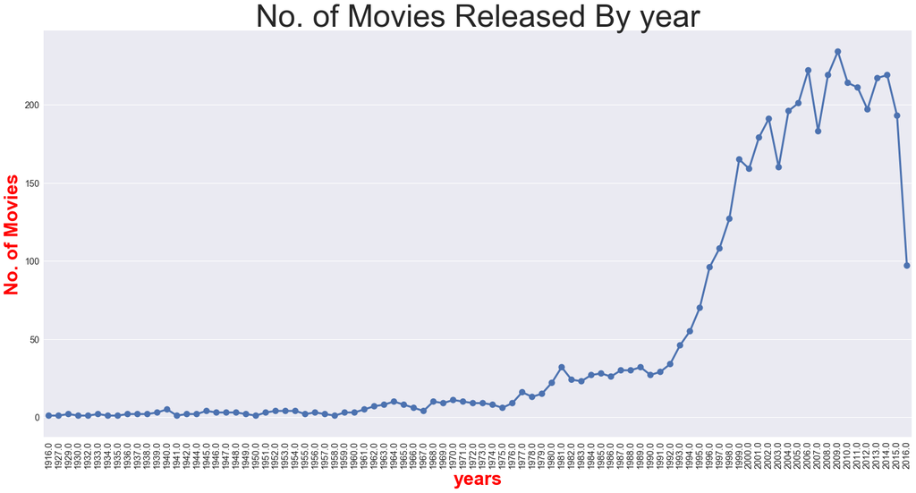

```python
s=cleaned.groupby('title_year').count()
plt.figure(figsize=(25,12))
sns.pointplot(x=np.array(s.index),y=s['budget'])
sns.regplot(x=np.array(s.index),y=s['budget'],scatter=False,lowess=True)
plt.xticks(x=s.index,rotation='vertical',size='x-large')
plt.yticks(size='x-large')

plt.xlabel("years",size=30,weight='heavy',color='red')
plt.ylabel('No. of Movies',weight='heavy',color='red',size=30)
plt.title('No. of Movies Released By year',size=50)

plt.show()
```

### Here I try to visualise the relationship between No. of voted users and vote_average by year .

We see an increasing trend in the No. of voted_users which is acompanied by decreasing vote_average this points tho the fact that the users are becoming more critical with the voting.

[figure not shown]

```python
wm=lambda x:np.average(x,weights=cleaned.loc[x.index,'num_voted_users'])
data=cleaned.groupby('title_year').aggregate({'vote_average':wm,'num_voted_users':lambda x:np.sum(x)})
scaler=preprocessing.MinMaxScaler((0,10))##Scaling to bring both the columns on same sacle
scaled=pd.DataFrame(scaler.fit_transform(data),columns=data.columns)
plt.figure(figsize=(25,12))
plt.plot(np.array(data.index),scaled['vote_average'],'r')
plt.plot(np.array(data.index),scaled['num_voted_users'],'b')
plt.xticks(x=data.index,rotation='vertical',size='x-large')
plt.yticks(size='x-large')

plt.xlabel("years",size=30,weight='heavy',color='red')

plt.legend(loc='upper left',fontsize=20)


plt.show()
```

```python
cleaned.columns
```

```
Index(['budget', 'genres', 'id', 'plot_keywords', 'language', 'original_title',
       'overview', 'popularity', 'production_companies',
       'production_countries', 'release_date', 'gross', 'duration',
       'spoken_languages', 'status', 'movie_title', 'vote_average',
       'num_voted_users', 'title_year', 'country', 'director_name',
       'actor_1_name', 'actor_2_name', 'actor_3_name', 'actor_1_gender',
       'actor_2_gender', 'actor_3_gender'],
      dtype='object')
```

## Who are the Most Popular Directors :-

1. By Imdb score or the vote_average
2. Average Income Grossed by the all their movies.

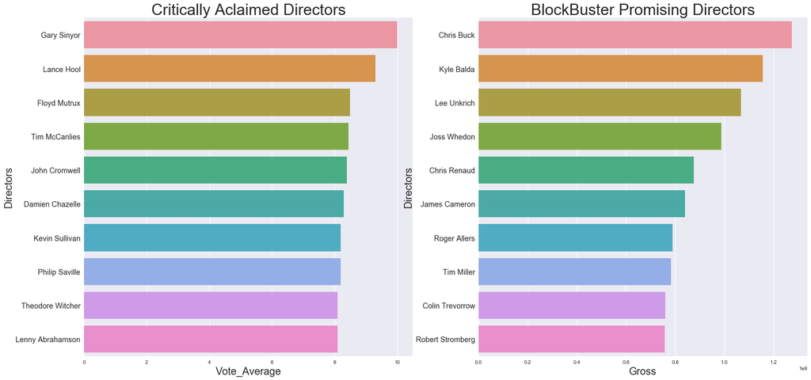

```python
##This is the popularity of directors By The Votes
great_directors=cleaned.groupby('director_name').agg({'gross':np.average,'vote_average':np.average})
g_gross=great_directors.sort_values('gross',ascending=False).reset_index().iloc[:10,:]
g_vote=great_directors.sort_values('vote_average',ascending=False).reset_index().iloc[:10,:]

fig,ax=plt.subplots(nrows=1,ncols=2,figsize=(25,12))
sns.barplot(y='director_name',x='vote_average',data=g_vote,ax=ax[0])
sns.barplot(y='director_name',x='gross',data=g_gross,ax=ax[1])
ax[0].set_yticklabels(labels=g_vote['director_name'],size='x-large')
ax[0].set_ylabel('Directors',size=20)
ax[0].set_xlabel('Vote_Average',size=20)
ax[0].set_title('Critically Aclaimed Directors',fontsize=30)
ax[1].set_yticklabels(labels=g_gross['director_name'],size='x-large')
ax[1].set_ylabel('Directors',size=20)
ax[1].set_xlabel('Gross',size=20)
ax[1].set_title('BlockBuster Promising Directors',fontsize=30)

plt.show()
```

## Corrplot reveals some important findings such as

1.Movies with High Budget tend to have High Income as well. 2.There is a strong corelation between Budget and Gross, which is a good new for directors:) 3.As expected critics have nothing to do with the budget .

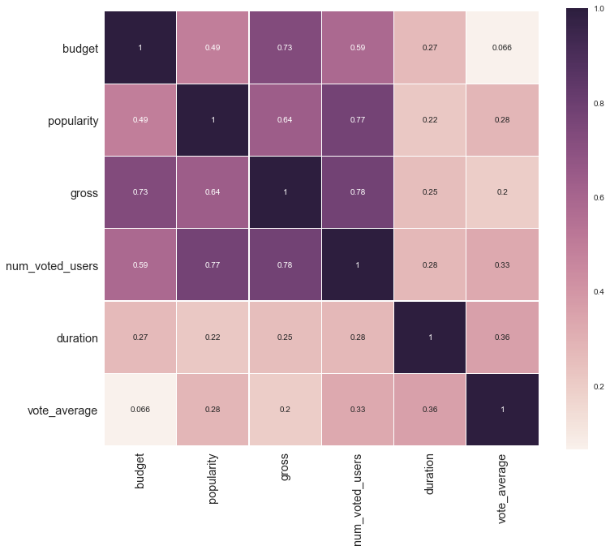

```python
new_data=cleaned[['budget','popularity','gross','num_voted_users','duration','vote_average']]
col=['budget', 'popularity', 'gross', 'voter_count', 'duration',
       'vote_average']
corr=new_data.corr()
plt.figure(figsize=(12,10))
sns.heatmap(corr,annot=True,square=True,linewidths=.15)
plt.xticks(label=col,size='x-large',rotation='vertical')
plt.yticks(y=col,size='x-large',rotation='horizontal')
plt.show()
```

## Female Protagonist

Here I have Divided the movies into three classes:

```python
df=cleaned[(cleaned['actor_1_gender']==1)&(cleaned['actor_2_gender']==2)&(cleaned['actor_3_gender']==2)][['actor_1_name','gross','popularity']].reset_index()
df1=cleaned[(cleaned['actor_1_gender']==1)&(cleaned['actor_2_gender']==1)&(cleaned['actor_3_gender']==2)][['actor_2_name','gross','popularity']].reset_index()
df2=cleaned[(cleaned['actor_1_gender']==1)&(cleaned['actor_2_gender']==1)&(cleaned['actor_3_gender']==1)][['actor_3_name','gross','popularity']].reset_index()
```

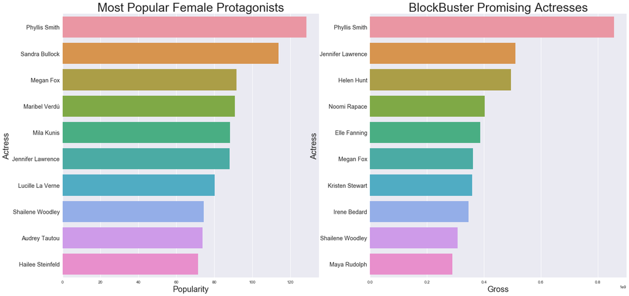

```python
df.columns=['index','Actress','gross','popularity']
df1.columns=['index','Actress','gross','popularity']
df2.columns=['index','Actress','gross','popularity']
s=pd.concat([df,df1,df2],axis=0)
s.drop('index',inplace=True,axis=1)
s=s[s['gross']!=0]
pro=s.groupby('Actress').agg({'gross':np.average}).reset_index()
grosser=pro.sort_values('gross',ascending=False).reset_index().drop('index',axis=1).iloc[:10,:]
pro=s.groupby('Actress').agg({'popularity':np.average}).reset_index()
popular=pro.sort_values('popularity',ascending=False).reset_index().drop('index',axis=1).iloc[:10,:]

fig,ax=plt.subplots(nrows=1,ncols=2,figsize=(25,12))
sns.barplot(y='Actress',x='popularity',data=popular,ax=ax[0])
sns.barplot(y='Actress',x='gross',data=grosser,ax=ax[1])
ax[0].set_yticklabels(labels=popular['Actress'],size='x-large')
ax[0].set_ylabel('Actress',size=20)
ax[0].set_xlabel('Popularity',size=20)
ax[0].set_title('Most Popular Female Protagonists',fontsize=30)
ax[1].set_yticklabels(labels=grosser['Actress'],size='x-large')
ax[1].set_ylabel('Actress',size=20)
ax[1].set_xlabel('Gross',size=20)
ax[1].set_title('BlockBuster Promising Actresses',fontsize=30)

plt.show()
```

## Let's Find out the most popular Genre

Here we Begin By getting a list of different genres

```python
temp=""
for i in cleaned.genres:
    temp=temp+'|'+i

genres_list=list(set(temp.split('|')))
del genres_list[0]##Data Cleaning.
genres_list
```

```
['Family',
 'War',
 'Action',
 'Science Fiction',
 'Horror',
 'Documentary',
 'Drama',
 'Mystery',
 'Music',
 'Adventure',
 'Thriller',
 'Crime',
 'Animation',
 'Western',
 'Comedy',
 'History',
 'Fantasy',
 'Foreign',
 'TV Movie',
 'Romance']
```

Now that we have a list of genres and each movie has multiple tags .We give each genre equal popularity for the movie they are tagged in.

```python
dict_genres=dict()
for i in genres_list:
    dict_genres[i]=[]

for i in range(len(cleaned.genres)):
    diff=cleaned.genres[i].split("|")
    for j in diff:
        if re.search(r'[a-zA-Z]+',j):
            dict_genres[j].append(cleaned.popularity[i])
```

Here we calculate the mean and standard Deviation assocaited with each genre because so as to take in account the standard error associated with each mean.

```python
genres=dict_genres.keys()
favourite_mean=[]
for i in genres:
    favourite_mean.append((np.array(dict_genres[i]).mean(),np.array(dict_genres[i]).std()/np.sqrt(len(dict_genres[i])),i))
top_10=sorted(favourite_mean,key=lambda x:x[0],reverse=True)
means,std,genres=zip(*top_10)
```

[output not shown]

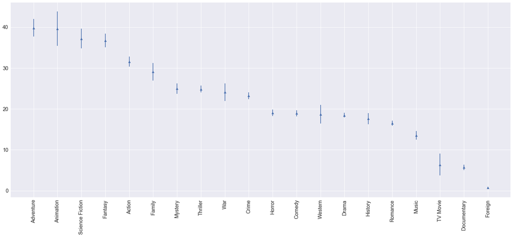

```python
plt.figure(figsize=(25,10))
x = np.arange(1,21,1)
y = means
labels = list(genres)
plt.errorbar(x, y,std,linestyle='None', marker='^')

plt.xticks(x, labels,rotation='vertical',size='x-large')
plt.yticks(size='x-large')
plt.show()
```

```python
list(genres)
```

```
['Adventure',
 'Animation',
 'Science Fiction',
 'Fantasy',
 'Action',
 'Family',
 'Mystery',
 'Thriller',
 'War',
 'Crime',
 'Horror',
 'Comedy',
 'Western',
 'Drama',
 'History',
 'Romance',
 'Music',
 'TV Movie',
 'Documentary',
 'Foreign']
```

# Plotly Pie chart Depicting the top_10 genres on Popularity score

This shows Adventure,animation and Science Fiction as top genres.

```python
labels=list(genres)[:10]
values=means[:10]
trace = go.Pie(labels=labels, values=values,
               hoverinfo='label+percent', textinfo='value',
               textfont=dict(size=20),
               marker=dict(line=dict(color='#000000', width=2)))

py.iplot([trace], filename='styled_pie_chart')
```

[interactive chart not shown]

# Word Cloud Based on No. of Movies For Each Genre

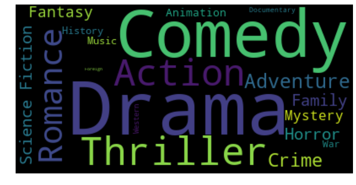

```python
dict_freq={}

for i in genres:
    dict_freq[i]=len(dict_genres[i])
wordcloud = WordCloud()
wordcloud.generate_from_frequencies(frequencies=dict_freq)
plt.figure(figsize=(12,25))
plt.imshow(wordcloud, interpolation="bilinear")
plt.axis('off')
plt.show()
```